# Impact of Major Storms and Weather Events in the United States

AllenTsai

2015年9月27日

Across the United States, Flood has greatest economic consequences. Due to National Weather Service Storm Database, it caused over 132,836,489,050 property damage, 5,170,955,450 crop damage, 138,007,444,500 total damage. In Central Standard Time Flood cause biggest impact on population health on 1998, but among all year tornado is most harmful.

In Pacific Standard Time, Flood casue biggest property damage on 2006. In Eastern Standard Time, Hurricane/Typhoon casuse biggest damage on 2004. In Central Standard Time Hurricane/Typhoon cause biggest damage on 2005.

### Data Processing

1. use fread to read data, extract csv from bz2 file before processing

```r
setwd("/Users/hadoop/RepData_PeerAssessment2")
#If you want to use fread, please install the dev version

source("installPackage.R")
```

[output not shown]

```r
setwd("/Users/hadoop")
data.file <-"repdata-data-StormData.csv"
if(require(data.table) && packageVersion("data.table") >= "1.9.5" ) {
        topData <- read.table(data.file, sep=",", nrows = 50, header=TRUE)
        col.classes <- sapply(topData, class)
        raw.data <- fread(data.file, header= TRUE, sep=",", colClasses = col.classes)
} else {
        raw.data <- read.table(data.file, sep=",", header = TRUE)
}
```

```
##
Read 28.9% of 967216 rows
Read 49.6% of 967216 rows
Read 67.2% of 967216 rows
Read 78.6% of 967216 rows
Read 91.0% of 967216 rows
Read 902297 rows and 37 (of 37) columns from 0.523 GB file in 00:00:07
```

2. cleaning data
- uppercase EVTYPE, TIME_ZONE, PROPDMGEXP, CROPDMGEXP
- ignore PROPDMGEXP/CROPDMGEXP not in (B,M,K)
- adjust PROPDMG by PROPDMGEXP (K = 1e3, M = 1e6, B= 1e9)
- adjust CROPDMG by CROPDMGEXP (K = 1e3, M = 1e6, B= 1e9)

```r
require(dplyr)
cleanData <- function(data) {
        clean.data <- data %>%
                mutate(EVTYPE = gsub("[^(a-zA-Z0-9/,)]",".", toupper(EVTYPE)) ) %>%
                mutate(TIME_ZONE = toupper(TIME_ZONE)) %>%
                mutate(PROPDMGEXP = toupper(PROPDMGEXP)) %>%
                mutate(CROPDMGEXP = toupper(CROPDMGEXP)) %>%
                filter(PROPDMGEXP %in% c("B","M","K")) %>%
                filter(CROPDMGEXP %in% c("B","M","K")) %>%
                mutate(BGN_DATE = as.Date(BGN_DATE, format="%m/%d/%Y")) %>%
                mutate(BGN_YR = year(BGN_DATE)) %>%
                mutate(BGN_DECADE = cut(BGN_YR, breaks = c(1949, 1959, 1969, 1979, 1989, 1999,2012) ) )%>%
                mutate(PROPDMG = ifelse(PROPDMGEXP == "K", PROPDMG * 1000,
                                        ifelse(PROPDMGEXP == "M", PROPDMG * 1000000,
                                               ifelse(PROPDMGEXP == "B", PROPDMG * 1000000000, PROPDMG ) ) )) %>%
                mutate(CROPDMG = ifelse(CROPDMGEXP == "K", CROPDMG * 1000,
                                        ifelse(CROPDMGEXP == "M", CROPDMG * 1000000,
                                               ifelse(CROPDMGEXP == "B", CROPDMG * 1000000000, CROPDMG ) ) ))
        levels(clean.data$BGN_DECADE) <- c('1950-1959', '1960-1969','1970-1979','1980-1989','1990-1999','2000-2011')
        return (clean.data)
}


clean.data <- cleanData(raw.data)
```

3. summary clean data by Event Type
- sum.FATALITIES
- sum.INJURIES
- sum.PROPDMG
- sum.CROPDMG
- sum.DMG = sum.PROPDMG + sum.CROPDMG
- sum.casualties = sum.FATALITIES + sum.INJURIES
- index.casualties = sum.FATALITIES * 3 + sum.INJURIES I gave FATALITIES a factor of 3 to calculate index.casualties

```r
require(dplyr)
summaryEventData <- function(cleanData) {
        summary.data <- cleanData %>%
                group_by(EVTYPE) %>%
                summarise(event.count=n() ,
                          sum.FATALITIES = sum(FATALITIES, na.rm= TRUE),
                          sum.INJURIES = sum(INJURIES, na.rm= TRUE),
                          sum.PROPDMG = sum(PROPDMG, na.rm= TRUE),
                          sum.CROPDMG = sum(CROPDMG, na.rm= TRUE)) %>%
                mutate(sum.DMG = sum.PROPDMG + sum.CROPDMG)  %>%
                mutate(sum.casualties = sum.FATALITIES  + sum.INJURIES) %>%
                mutate(index.casualties = sum.FATALITIES * 3 + sum.INJURIES)
        return (summary.data)
}

summary.event.data <- summaryEventData(clean.data)
```

### Result

#### Summary Damage by Event Type

1. order by sum.DMG descending, get top 20 event
2. economic damaage(property and crop) by event type

```r
require(ggplot2)
summary.dmg.data <- summary.event.data %>%
        arrange(desc(sum.DMG)) %>%
        top_n(20) %>%
        select(EVTYPE, c(1,5,6,7))
p1 <- ggplot(summary.dmg.data, aes(x=EVTYPE, y=sum.DMG))  +
        geom_bar(stat="identity")  +
        labs(title = "Total damages casuse by Top 20 Weather Event") +
        labs(y = "Estimates of Damage (property + crop) ") +
        labs(x = "Event Type") +
        theme(axis.text.x= element_text(angle=90, vjust=0.6, size=8))+
        theme(title= element_text(vjust=0.6, size=8))
```

#### Summary Casualties by Event Type

1. order by index.casualties descending, get top 20 event
2. human health impact(fatalities + injuries)

```r
require(ggplot2)
summary.casualties.data <- summary.event.data %>%
        arrange(desc(index.casualties)) %>%
        top_n(20) %>%
        select(EVTYPE, c(1,3,4,8,9))
p2 <- ggplot(summary.casualties.data, aes(x=EVTYPE, y=sum.casualties))  +
        geom_bar(stat="identity")  +
        labs(title = "Total Casualties casuse by Top 20 Weather Event") +
        labs(y = "Casualties (fatalities + injuries) ") +
        labs(x = "Event Type") +
        theme(axis.text.x= element_text(angle=90, vjust=0.6, size=8))+
        theme(title= element_text(vjust=0.6, size=8))
```

plot damage/casualities by Event Type

```r
setwd("/Users/hadoop/RepData_PeerAssessment2")
require(grid)
```

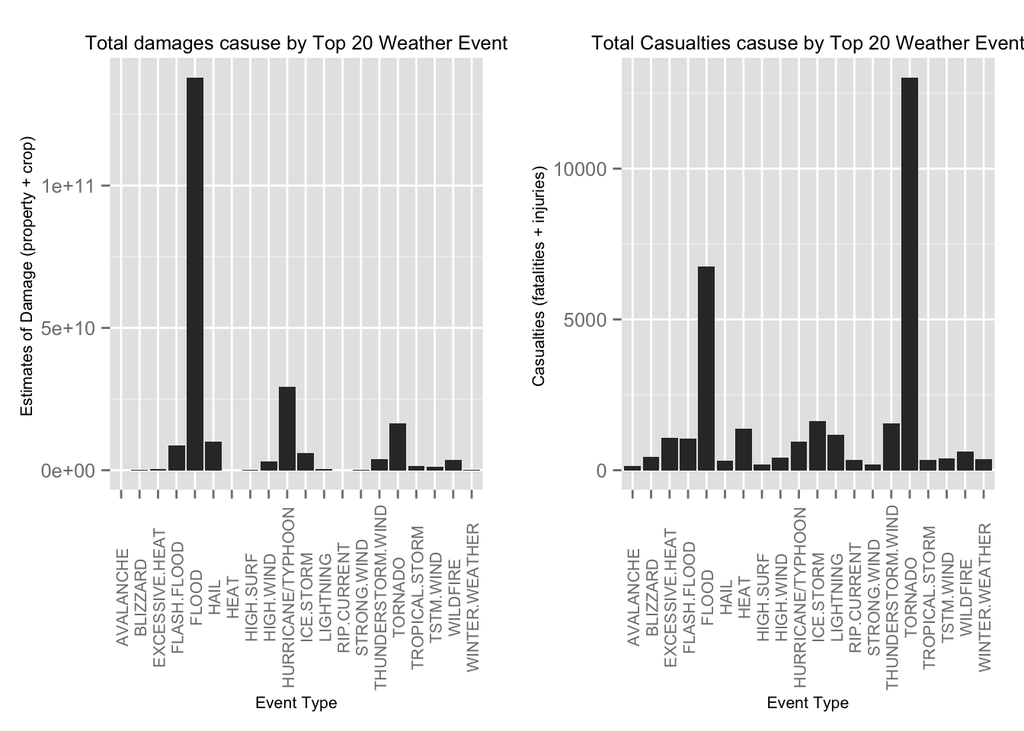

```r
source("multiplot.R")
multiplot(p1, p2, cols=2)
```

#### Summary Damage by Top3 Event Across the United States

1. pickup TIME_ZONE(CST,EST, MST, PST)
2. pickup top 3 EVENT TYPE (Flood, Hurrican/Typhoon, Tornado)
3. draw damage (property+crop) by year of event http://www.timeanddate.com/time/zones/pst

In Pacific Standard Time, Flood (California, Idaho,Nevada,Oregon,Washington)

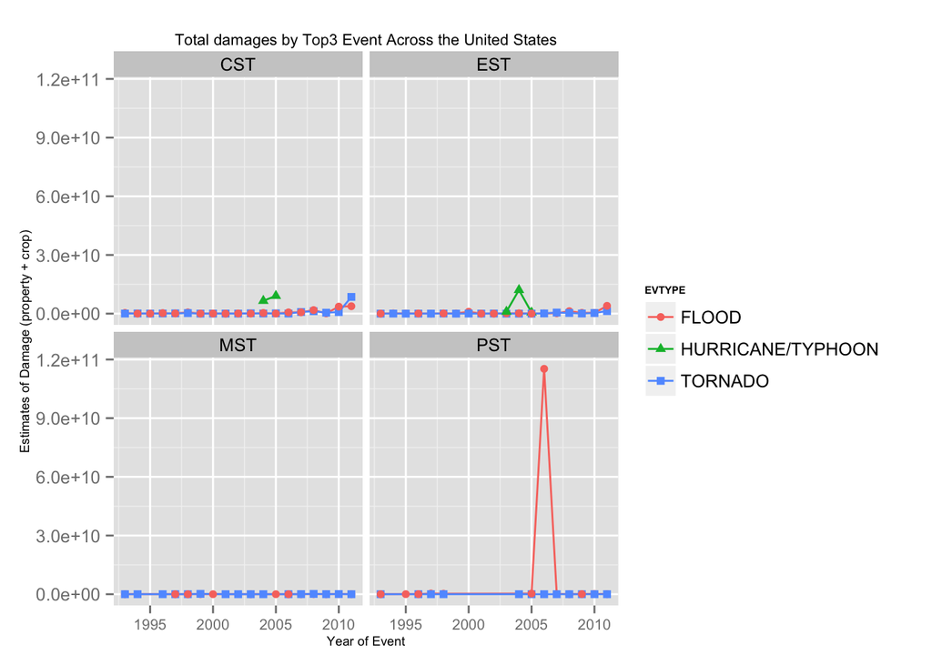

```r
summary.damage <- clean.data %>%
            filter(EVTYPE %in% as.data.frame(summary.dmg.data)[1:3,1]) %>%
            filter(TIME_ZONE %in% c("PST","MST","EST","CST")) %>%
            group_by(EVTYPE,BGN_YR,TIME_ZONE) %>%
            summarise(event.count=n() ,
                  sum.PROPDMG = sum(PROPDMG, na.rm= TRUE),
                  mean.PROPDMG = mean(PROPDMG, na.rm= TRUE),
                  sum.CROPDMG = sum(CROPDMG, na.rm= TRUE),
                  mean.CROPDMG = mean(CROPDMG, na.rm= TRUE)) %>%
        mutate(sum.Damage = sum.PROPDMG + sum.CROPDMG)  %>%
        mutate(mean.Damage = mean.PROPDMG + mean.CROPDMG)

pd1 <-  ggplot(aes(x=BGN_YR, col=EVTYPE), data=summary.damage) +
        geom_line(aes(y= sum.Damage))+
        geom_point(aes(y= sum.Damage, shape=EVTYPE))+
        facet_wrap(~ TIME_ZONE, ncol=2) +
        labs(title = "Total damages by Top3 Event Across the United States" ) +
        labs(y = "Estimates of Damage (property + crop)") +
        labs(x = "Year of Event")  +
        theme(title=element_text(vjust=0.5,hjust=0.5, size=7))+
        theme(axis.text.x= element_text(angle=0, vjust=0.5, size=8))
plot(pd1)
```

#### Total Casualties by Top3 Event Across the United States

1. pickup TIME_ZONE(CST,EST, MST, PST)
2. pickup top 3 EVENT TYPE (Flood, Flash.Flood, Tornado)
3. draw casualities (FATALITIES+INJURIES) by year of event http://www.timeanddate.com/time/zones/cst http://www.timeanddate.com/time/zones/est

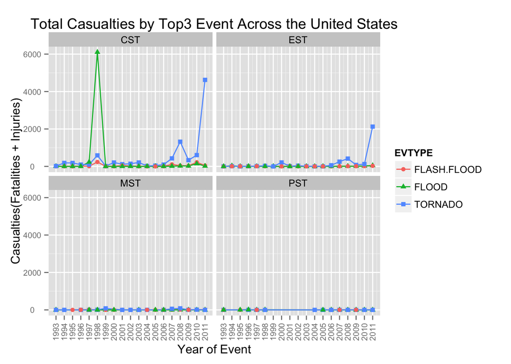

```r
summary.casualties <- clean.data %>%
        filter(EVTYPE %in% as.data.frame(summary.casualties.data)[1:3,1]) %>%
        filter(TIME_ZONE %in% c("PST","MST","EST","CST")) %>%
        group_by(EVTYPE,BGN_YR,TIME_ZONE) %>%
        summarise(event.count=n() ,
                  sum.FATALITIES = sum(FATALITIES, na.rm= TRUE),
                  sum.INJURIES = sum(INJURIES, na.rm= TRUE)) %>%
        mutate(sum.Casualties = sum.FATALITIES + sum.INJURIES)


pc1 <- ggplot(aes(x=BGN_YR, col=EVTYPE), data=summary.casualties) +
        geom_line(aes(y= sum.Casualties, col=EVTYPE))+
        geom_point(aes(y= sum.Casualties, shape=EVTYPE))+
        scale_x_continuous(breaks=unique(summary.casualties$BGN_YR)) +
        facet_wrap(~ TIME_ZONE) +
        labs(title = "Total Casualties by Top3 Event Across the United States" ) +
        labs(y = "Casualties(Fatalities + Injuries)") +
        labs(x = "Year of Event")  +
        theme(axis.text.y=element_text(vjust=0.5,hjust=0.5, size=8))+
        theme(axis.text.x= element_text(angle=90, vjust=0.5, size=8))

plot(pc1)
```